# Imputation quality filters for high-density stores

Choosing MAF / imputation-r² cutoffs before importing TOPMed-imputed summary statistics

Published

July 14, 2026

```r
library(data.table)
library(ggplot2)
library(scales)

## Parameters ----------------------------------------------------------
## Point `accession` / `url` at any GWAS-SSF harmonised analysis to re-run.
## The MVP proteome store (dense__pmid-39024449__European) is the motivating
## case: ~44.3M variants per analysis, TOPMed-imputed.
accession <- "GCST90477290"
url <- paste0("http://ftp.ebi.ac.uk/pub/databases/gwas/summary_statistics/",
              "GCST90477001-GCST90478000/", accession,
              "/harmonised/", accession, ".h.tsv.gz")
data_dir <- "../data/mvp-example"
local_gz <- file.path(data_dir, basename(url))

## Store-size translation (matches ebi-studies.r).
n_analyses_store <- 3360     # analyses in the MVP European store
bytes_per_cell <- 2.5
gb <- function(n_variants) n_analyses_store * n_variants * bytes_per_cell / 1e9

fmt_int <- function(x) formatC(x, format = "d", big.mark = ",")
```

## Why this matters

The MVP store is imputed to ~44.3M variants per analysis. At 2.5 bytes/cell that is 372 GB for the store — and much of that tail is rare, low-confidence imputed variants. This document looks at **one analysis** to decide MAF / imputation-r² cutoffs before import. Because size scales linearly with the retained variant count, the filter directly sets the store’s cost and credibility.

> Scope: a single analysis. Imputation r² varies across analyses, so confirm the chosen thresholds on a few more before locking them in — re-run this doc with a different `accession`.

```r
dir.create(data_dir, showWarnings = FALSE, recursive = TRUE)
if (!file.exists(local_gz)) {
  options(timeout = 7200)
  download.file(url, local_gz, mode = "wb", quiet = TRUE)
}
sprintf("%s: %.1f GB on disk", basename(local_gz), file.size(local_gz) / 1e9)
```

```
[1] "GCST90477290.h.tsv.gz: 2.1 GB on disk"
```

```r
## Read only the two columns we need (fast, low memory on a ~10GB file), derive
## MAF, and bin it. Cached: this is the slow step; everything below is instant.
hdr <- names(fread(local_gz, nrows = 0))
freq_col <- intersect(c("effect_allele_frequency", "EAF", "eaf"), hdr)[1]
info_col <- intersect(c("r2", "info", "imputation_quality", "INFO", "IMPINFO"), hdr)[1]
stopifnot(!is.na(freq_col), !is.na(info_col))

dat <- fread(local_gz, select = c(freq_col, info_col))
setnames(dat, c(freq_col, info_col), c("eaf", "r2"))
dat <- dat[!is.na(eaf) & !is.na(r2)]
dat[, maf := pmin(eaf, 1 - eaf)]
dat <- dat[maf > 0 & maf <= 0.5]

maf_breaks <- c(0, 1e-4, 1e-3, 5e-3, 1e-2, 5e-2, 0.1, 0.2, 0.5)
maf_labels <- c("<0.0001", "0.0001–0.001", "0.001–0.005", "0.005–0.01",
                "0.01–0.05", "0.05–0.1", "0.1–0.2", "0.2–0.5")
dat[, maf_bin := cut(maf, breaks = maf_breaks, labels = maf_labels,
                     include.lowest = TRUE)]
n_total <- nrow(dat)
sprintf("%s variants with MAF and r2 (info column: '%s').", fmt_int(n_total), info_col)
```

```
[1] "36,913,281 variants with MAF and r2 (info column: 'r2')."
```

## Distributions

```r
knitr::kable(
  rbind(
    data.table(metric = "MAF", t(round(quantile(dat$maf, c(0,.25,.5,.75,1)), 4))),
    data.table(metric = "r2",  t(round(quantile(dat$r2,  c(0,.25,.5,.75,1)), 3)))
  ),
  col.names = c("", "min", "Q1", "median", "Q3", "max"),
  caption = "Distribution of minor allele frequency and imputation r².")
```

Distribution of minor allele frequency and imputation r².

|  | min | Q1 | median | Q3 | max |
| --- | --- | --- | --- | --- | --- |
| MAF | 1e-04 | 0.001 | 0.0055 | 0.0473 | 0.500 |
| r2 | 3e-01 | 0.615 | 0.7840 | 0.8910 | 1.556 |

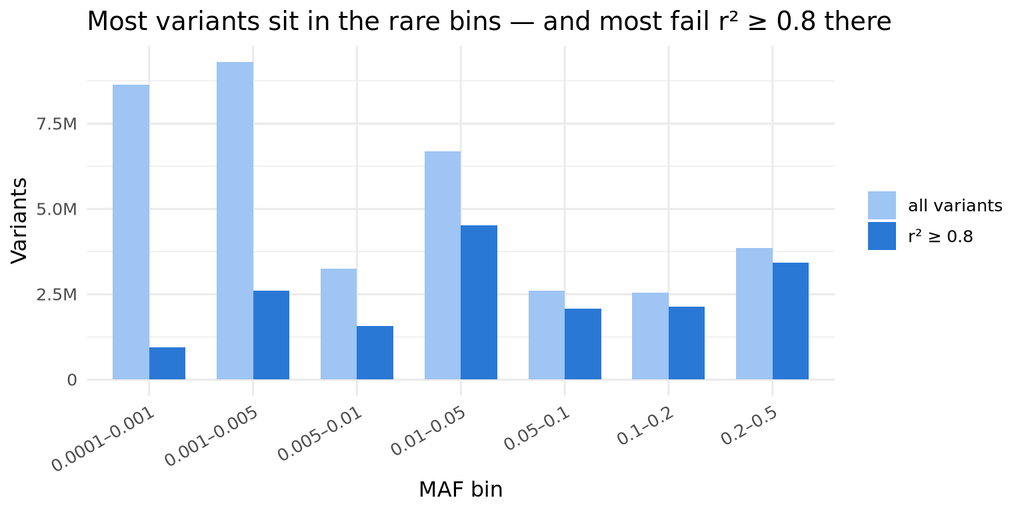

```r
mafd <- dat[, .(all = .N, pass = sum(r2 >= 0.8)), by = maf_bin][order(maf_bin)]
mafd <- melt(mafd, id.vars = "maf_bin", variable.name = "set", value.name = "n")
mafd[, set := factor(set, c("all", "pass"), c("all variants", "r² ≥ 0.8"))]
ggplot(mafd, aes(maf_bin, n, fill = set)) +
  geom_col(position = "dodge", width = 0.7) +
  scale_fill_manual(values = c("all variants" = "#9ec5f4", "r² ≥ 0.8" = "#2a78d6")) +
  scale_y_continuous(labels = label_number(scale_cut = cut_short_scale())) +
  labs(x = "MAF bin", y = "Variants", fill = NULL,
       title = "Most variants sit in the rare bins — and most fail r² ≥ 0.8 there") +
  theme_minimal(base_size = 12) +
  theme(axis.text.x = element_text(angle = 30, hjust = 1))
```

## Imputation r² by MAF bin

The core question: rare variants impute worse, so a single r² cutoff is either too lax for common variants or too harsh for rare ones. This is the evidence for a **MAF-dependent** threshold.

```r
byb <- dat[, .(
  n = .N,
  median_r2 = round(median(r2), 3),
  q25 = round(quantile(r2, .25), 3),
  q75 = round(quantile(r2, .75), 3),
  pct_pass_0.3 = round(100 * mean(r2 >= 0.3), 1),
  pct_pass_0.8 = round(100 * mean(r2 >= 0.8), 1)
), by = maf_bin][order(maf_bin)]
knitr::kable(byb, format.args = list(big.mark = ","),
  col.names = c("MAF bin", "n", "median r²", "r² Q1", "r² Q3",
                "% pass 0.3", "% pass 0.8"),
  caption = "Imputation r² collapses in the rare bins.")
```

Imputation r² collapses in the rare bins.

| MAF bin | n | median r² | r² Q1 | r² Q3 | % pass 0.3 | % pass 0.8 |
| --- | --- | --- | --- | --- | --- | --- |
| 0.0001–0.001 | 8,644,909 | 0.547 | 0.418 | 0.694 | 100 | 11.1 |
| 0.001–0.005 | 9,309,423 | 0.706 | 0.574 | 0.813 | 100 | 28.0 |
| 0.005–0.01 | 3,254,360 | 0.795 | 0.699 | 0.870 | 100 | 48.4 |
| 0.01–0.05 | 6,689,759 | 0.851 | 0.773 | 0.912 | 100 | 67.7 |
| 0.05–0.1 | 2,607,587 | 0.894 | 0.819 | 0.948 | 100 | 79.4 |
| 0.1–0.2 | 2,541,993 | 0.905 | 0.838 | 0.955 | 100 | 83.8 |
| 0.2–0.5 | 3,865,250 | 0.915 | 0.860 | 0.954 | 100 | 88.4 |

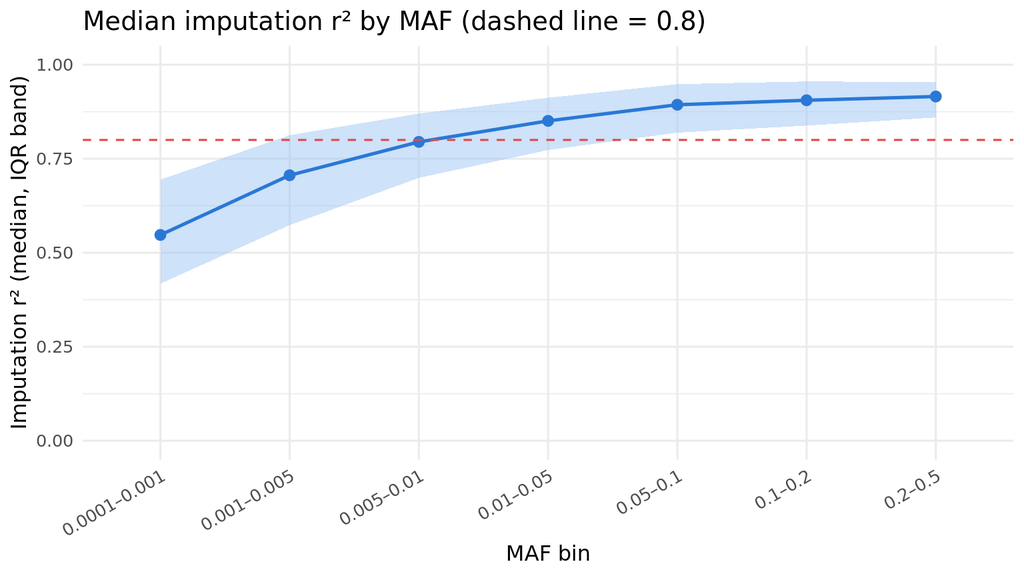

```r
byplot <- dat[, .(median_r2 = median(r2),
                  q25 = quantile(r2, .25), q75 = quantile(r2, .75)), by = maf_bin][order(maf_bin)]
ggplot(byplot, aes(maf_bin, median_r2, group = 1)) +
  geom_ribbon(aes(ymin = q25, ymax = q75), fill = "#9ec5f4", alpha = 0.5) +
  geom_line(colour = "#2a78d6", linewidth = 0.9) +
  geom_point(colour = "#2a78d6", size = 2.4) +
  geom_hline(yintercept = 0.8, linetype = "dashed", colour = "#e34948") +
  scale_y_continuous(limits = c(0, 1)) +
  labs(x = "MAF bin", y = "Imputation r² (median, IQR band)",
       title = "Median imputation r² by MAF (dashed line = 0.8)") +
  theme_minimal(base_size = 12) +
  theme(axis.text.x = element_text(angle = 30, hjust = 1))
```

## Retention grid: what survives each (MAF, r²) cutoff

For every combination of a MAF floor and an r² floor, how many variants remain — and what would the store cost if imported at that density?

```r
maf_thr <- c(0, 1e-4, 1e-3, 5e-3, 1e-2, 5e-2)
r2_thr <- c(0.3, 0.5, 0.7, 0.8, 0.9)
retention <- rbindlist(lapply(maf_thr, function(m) {
  r2v <- dat[maf >= m, r2]
  data.table(maf_min = m, r2_min = r2_thr,
             n_retained = vapply(r2_thr, function(r) sum(r2v >= r), numeric(1)))
}))
retention[, pct := round(100 * n_retained / n_total, 1)]
retention[, est_store_gb := round(gb(n_retained))]
```

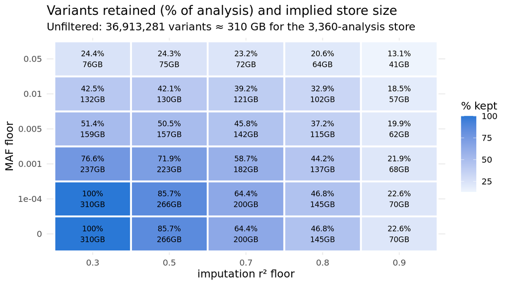

```r
ggplot(retention, aes(factor(r2_min), factor(maf_min), fill = pct)) +
  geom_tile(colour = "white", linewidth = 1) +
  geom_text(aes(label = paste0(pct, "%\n", est_store_gb, "GB")), size = 3) +
  scale_fill_gradient(low = "#eef4fd", high = "#2a78d6", name = "% kept") +
  labs(x = "imputation r² floor", y = "MAF floor",
       title = "Variants retained (% of analysis) and implied store size",
       subtitle = paste0("Unfiltered: ", fmt_int(n_total), " variants ≈ ",
                         round(gb(n_total)), " GB for the ", fmt_int(n_analyses_store),
                         "-analysis store")) +
  theme_minimal(base_size = 12)
```

```r
knitr::kable(
  dcast(retention, maf_min ~ r2_min, value.var = "pct"),
  caption = "Percent of variants retained by MAF floor (rows) × r² floor (cols).")
```

Percent of variants retained by MAF floor (rows) × r² floor (cols).

| maf_min | 0.3 | 0.5 | 0.7 | 0.8 | 0.9 |
| --- | --- | --- | --- | --- | --- |
| 0e+00 | 100.0 | 85.7 | 64.4 | 46.8 | 22.6 |
| 1e-04 | 100.0 | 85.7 | 64.4 | 46.8 | 22.6 |
| 1e-03 | 76.6 | 71.9 | 58.7 | 44.2 | 21.9 |
| 5e-03 | 51.4 | 50.5 | 45.8 | 37.2 | 19.9 |
| 1e-02 | 42.5 | 42.1 | 39.2 | 32.9 | 18.5 |
| 5e-02 | 24.4 | 24.3 | 23.2 | 20.6 | 13.1 |

## A tiered proposal

A single cutoff wastes either credibility or common-variant coverage. One defensible tiered rule — **stricter r² where imputation is least reliable**:

- MAF ≥ 0.01 → r² ≥ 0.3
- 0.001 ≤ MAF < 0.01 → r² ≥ 0.8
- MAF < 0.001 → drop (imputation not trustworthy at this frequency)

```r
dat[, keep_tiered :=
      (maf >= 0.01 & r2 >= 0.3) |
      (maf >= 0.001 & maf < 0.01 & r2 >= 0.8)]
tiered_n <- sum(dat$keep_tiered)

compare <- data.table(
  policy = c("unfiltered",
             "flat: MAF≥0.01 & r²≥0.3",
             "flat: MAF≥0.01 & r²≥0.8",
             "tiered (above)"),
  n_variants = c(n_total,
                 dat[maf >= 0.01 & r2 >= 0.3, .N],
                 dat[maf >= 0.01 & r2 >= 0.8, .N],
                 tiered_n)
)
compare[, pct_of_unfiltered := round(100 * n_variants / n_total, 1)]
compare[, est_store_gb := round(gb(n_variants))]
knitr::kable(compare, format.args = list(big.mark = ","),
  col.names = c("Policy", "Variants / analysis", "% of unfiltered", "Est. store GB"),
  caption = "Effect of candidate import policies on variant count and store size.")
```

Effect of candidate import policies on variant count and store size.

| Policy | Variants / analysis | % of unfiltered | Est. store GB |
| --- | --- | --- | --- |
| unfiltered | 36,913,281 | 100.0 | 310 |
| flat: MAF≥0.01 & r²≥0.3 | 15,704,589 | 42.5 | 132 |
| flat: MAF≥0.01 & r²≥0.8 | 12,147,760 | 32.9 | 102 |
| tiered (above) | 19,881,228 | 53.9 | 167 |

## Takeaways

```r
common_lax <- dat[maf >= 0.01 & r2 >= 0.3, .N]
cat(sprintf(
"- Unfiltered: %s variants/analysis -> ~%d GB store.\n",
  fmt_int(n_total), round(gb(n_total))))
```

```
- Unfiltered: 36,913,281 variants/analysis -> ~310 GB store.
```

```r
cat(sprintf(
"- Common, lightly filtered (MAF>=0.01, r2>=0.3): %s variants (%.0f%%) -> ~%d GB.\n",
  fmt_int(common_lax), 100*common_lax/n_total, round(gb(common_lax))))
```

```
- Common, lightly filtered (MAF>=0.01, r2>=0.3): 15,704,589 variants (43%) -> ~132 GB.
```

```r
cat(sprintf(
"- Tiered policy: %s variants (%.0f%%) -> ~%d GB.\n",
  fmt_int(tiered_n), 100*tiered_n/n_total, round(gb(tiered_n))))
```

```
- Tiered policy: 19,881,228 variants (54%) -> ~167 GB.
```